# Birds in my neighbourhood across autumn

Sofie Wigram (swig143)

## The backstory

For Project 2 (in March) I decided to go on twice-daily walks on consecutive days on a set route in my neighbourhood and record how many of each of five types of birds I sighted on my walks. For Project 4 (in May) I went on the same number of walks in the same manner and observed the birds again. Here’s what I noticed…

## Plot 1: Why are seagulls impervious to weather?

The weather back in March was fairly uniform (sunny, with a few grey days thrown in) and not very useful for comparison. Now in May, the weather was far more variable and interesting. I decided to split my daily walks into weather types, and look at the average number of birds sighted for each weather type.

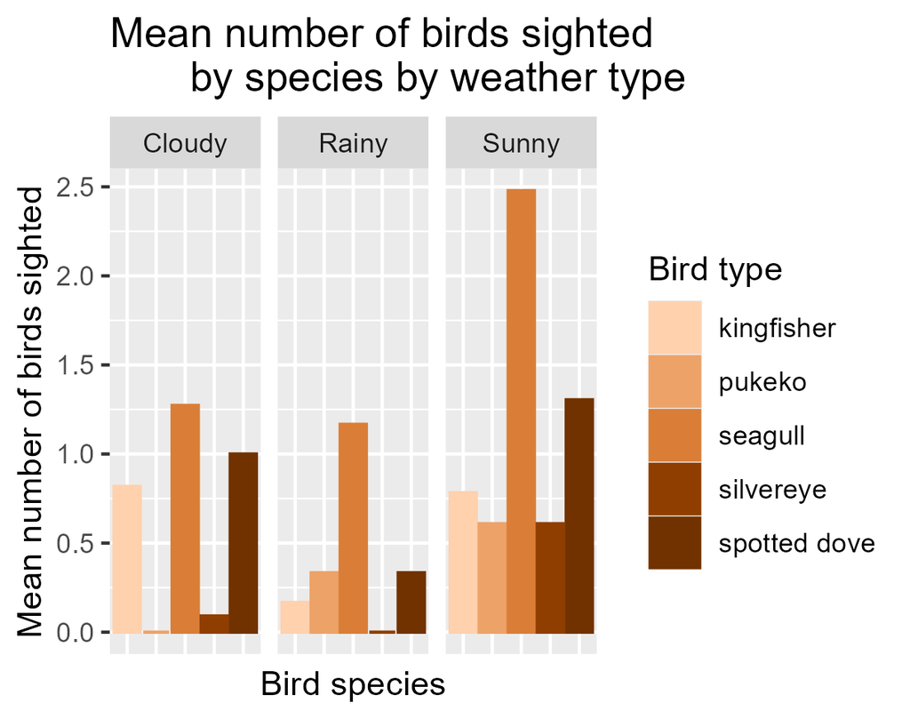

bar plot of mean bird counts per species by weather type, showing seagulls having a higher mean count than other bird types across weather types

Unsurprisingly, I saw the most birds on sunny days. But I can’t help but notice the orange bar in the centre of each plot–the humble seagull. Seagulls in my neighbourhood appear to be surprisingly resilient to rainy weather compared to other species.

## A digression about timestamps (feat. a bonus plot):

I logged my bird sighting data with pencil and paper during walks and then uploaded to my Google form in batches whenever I had a spare moment. This means I have two time variables in my data: the timestamp variable which shows the date I entered my observations to the Google form, and the walk_date variable, which shows the date the walk actually occurred.

Unfortunately, this makes the timestamp variable fairly useless for my purposes. By converting both time variables to dmy format and subtracting one from the other, we can find how many days after the walk I uploaded the data to the Google form. I’ve created a plot of this data to illustrate:

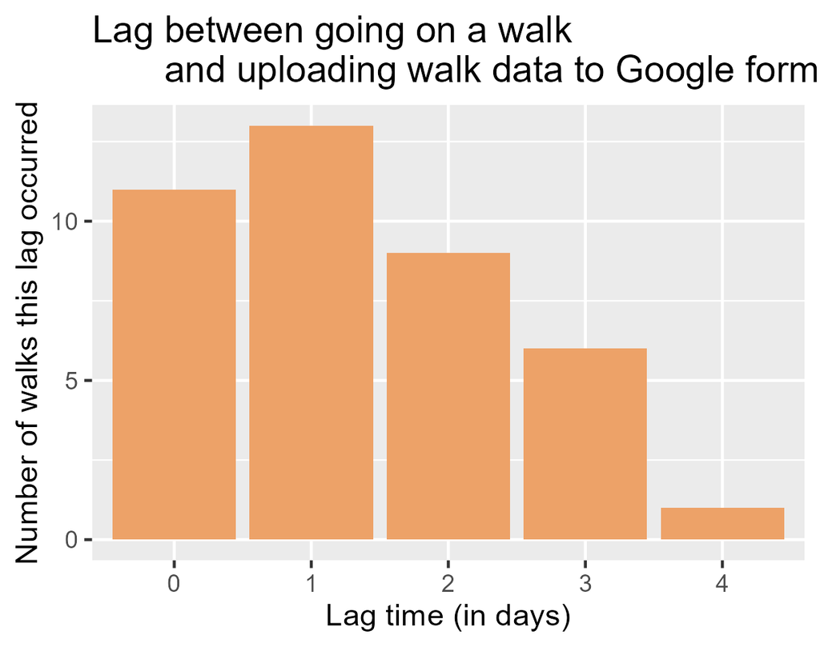

bar plot showing the difference between the timestamp and walk_date variable in days

## Plot 2: Autumn, season of mists and mellow fruitfulness

For Project 2, I tallied up the bird sightings of all species in the mornings and afternoons across time, and noticed that there were (predictably) more bird sightings in the mornings.

I’ve looked at my data again through the lens of mornings vs afternoons, and we can see the same pattern. However, take a look:

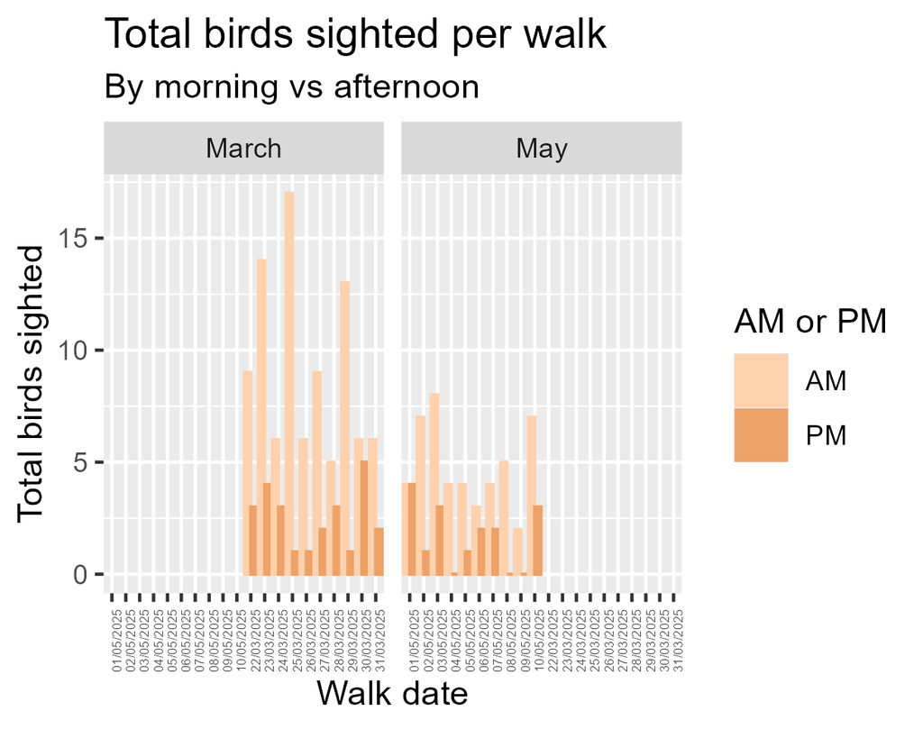

plot of AM vs PM total bird sightings per month, showing more sightings in AM than PM, and more sightings in March than May

The walks that took place in March have notably more bird sightings on average than those that took place in May. I assume we’re seeing the changing of the seasons and the coming of cold weather at play.

## Plot 3A & 3B: a closer look at the above data in two ways

Because it’s a little confusing to look at mornings vs afternoons as well as March vs May at the same time, I decided to split this information apart.

First, we can look at this data by month. As we might expect, we can see that the May count of total birds sighted is much lower on average than March–March has higher counts, which are therefore more spread out. The effect of seasonal change seems clear here.

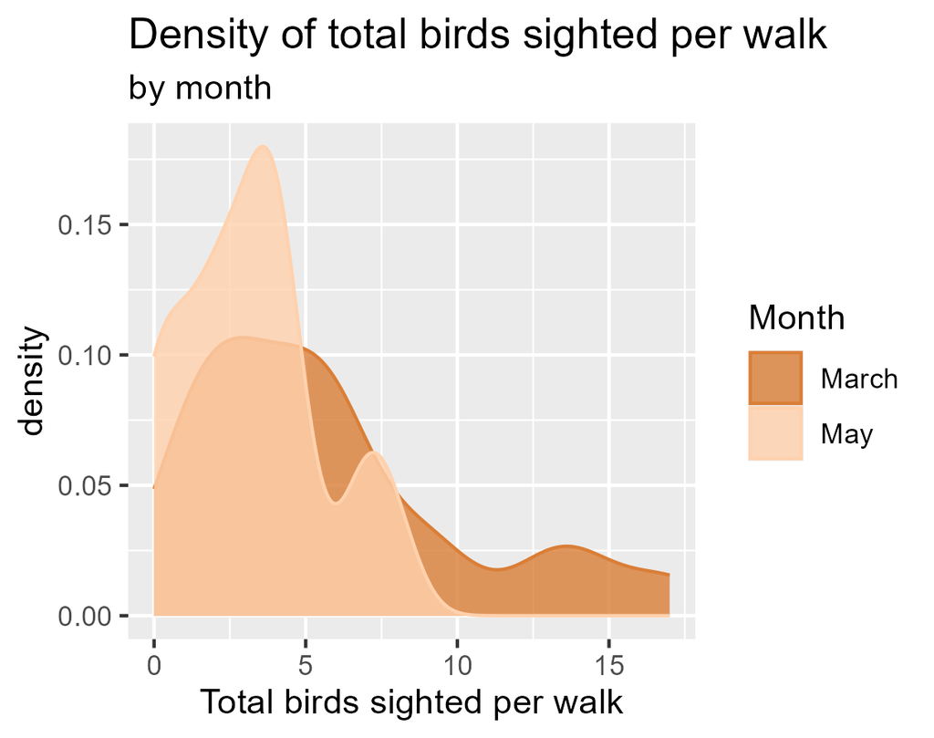

A similar kind of structure can be seen if we instead split by morning vs afternoon (AM vs PM) walks–we can see that the afternoon walks tend to have a smaller number of birds sighted, and the morning walks have a larger number of birds sighted that are therefore more spread out on the plot.

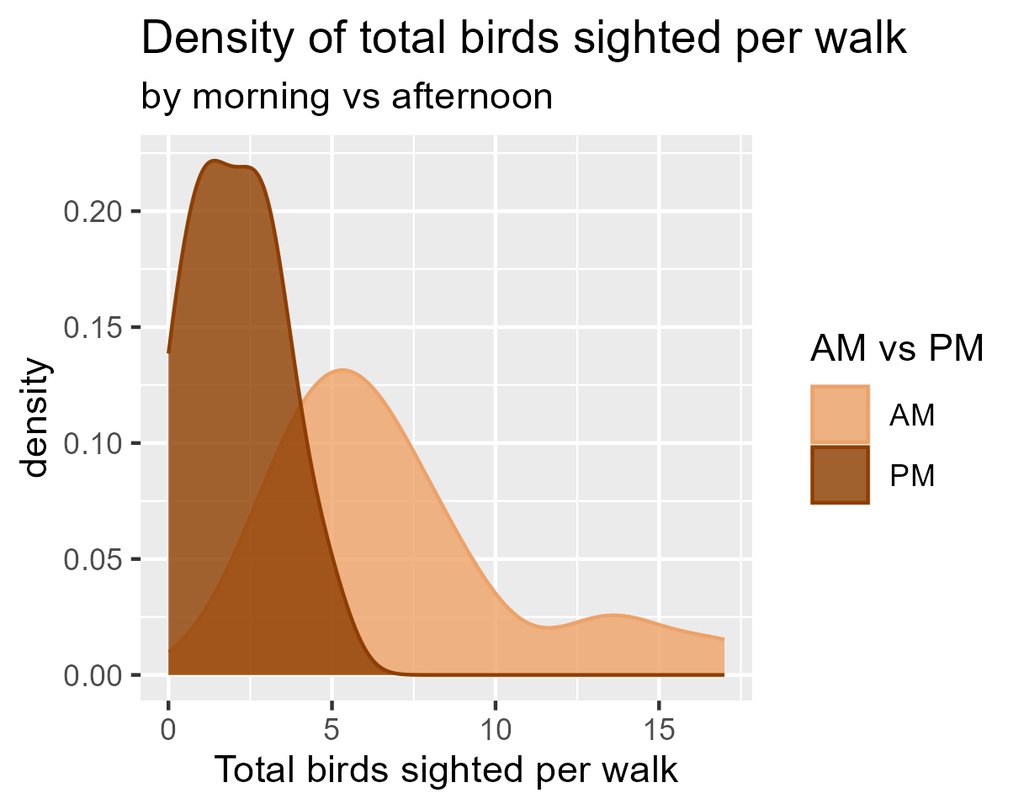

density plot showing total bird sightings by morning vs afternoon, showing higher counts in the mornings